This vignette shows how to measure asymptotic performance of regular expression engines. First we define a grid of data sizes.

```r
(subject.size.vec <- unique(as.integer(10^seq(0,3.5,l=100))))
```

```
#>  [1]    1    2    3    4    5    6    7    8    9   10   11   12   13   14   15
#> [16]   17   18   20   22   23   25   28   30   33   35   38   42   45   49   53
#> [31]   58   63   68   74   81   87   95  103  112  121  132  143  155  168  183
#> [46]  198  215  233  253  275  298  323  351  380  413  448  486  527  572  620
#> [61]  673  730  792  859  932 1011 1097 1190 1291 1401 1519 1648 1788 1940 2104
#> [76] 2283 2477 2687 2915 3162
```

Then we define a list of R expressions that run the regex `pattern` on `subject`. Note that neither `subject` nor `pattern` are defined yet, and that is OK. These expressions will be evaluated later, so we can define `subject` and `pattern` to depend on data size. The list is called `backtrackers` because these are the regex engines which use backtracking, and are therefore worst case exponential time complexity.

```r
(backtrackers <- c(
  if(requireNamespace("stringi"))atime::atime_grid(
    ICU=stringi::stri_match(subject, regex=pattern)),
  atime::atime_grid(
    PCRE=regexpr(pattern, subject, perl=TRUE),
    TRE=regexpr(pattern, subject, perl=FALSE))))
```

```
#> $ICU
#> stringi::stri_match(subject, regex = pattern)
#>
#> $PCRE
#> regexpr(pattern, subject, perl = TRUE)
#>
#> $TRE
#> regexpr(pattern, subject, perl = FALSE)
#>
```

The code below executes `setup` for every value in `N`, which defines `subject` and `pattern` to be a pathological combination that results in the worst case time complexity.

```
#> log-10 transformation introduced infinite values.
```

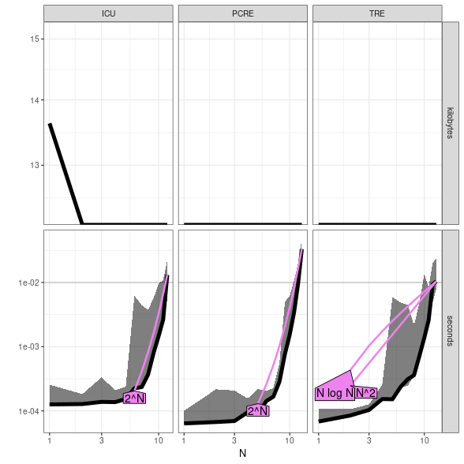

```r
backtrackers.result <- atime::atime(
  N=subject.size.vec,
  setup={
    subject <- paste(rep("a", N), collapse="")
    pattern <- paste(rep(c("(a)?", "\\1"), each=N), collapse="")
  },
  expr.list=backtrackers)
backtrackers.best <- atime::references_best(backtrackers.result)
plot(backtrackers.best)
```

The code below creates a list with a fourth regex engine, RE2, that uses a different algorithm (not backtracking, so worst case polynomial time is much faster).

```r
(all.exprs <- c(
  if(requireNamespace("re2"))atime::atime_grid(
    RE2=re2::re2_match(subject, pattern)),
  backtrackers))
```

```
#> $RE2
#> re2::re2_match(subject, pattern)
#>
#> $ICU
#> stringi::stri_match(subject, regex = pattern)
#>
#> $PCRE
#> regexpr(pattern, subject, perl = TRUE)
#>
#> $TRE
#> regexpr(pattern, subject, perl = FALSE)
#>
```

Below we run the same `subject` with a different `pattern`, which does not include the `\1` backreference (that feature is not supported in RE2, which is why is achieves a better worst case time complexity).

```
#> log-10 transformation introduced infinite values.
```

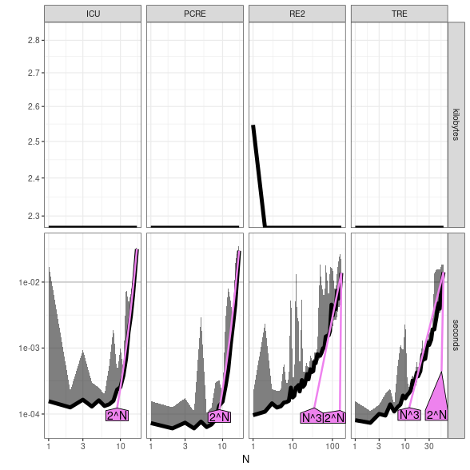

```r
all.result <- atime::atime(
  N=subject.size.vec,
  setup={
    subject <- paste(rep("a", N), collapse="")
    pattern <- paste(rep(c("a?", "a"), each=N), collapse="")
  },
  expr.list=all.exprs)
all.best <- atime::references_best(all.result)
plot(all.best)
```

The plot above shows that ICU/PCRE are exponential time whereas RE2/TRE are polynomial time. Exercise for the reader: modify the above code to use the `seconds.limit` argument so that you can see what happens to ICU/PCRE for larger N (hint: you should see a difference at larger sizes).

## Interpolate at seconds.limit using predict method

Typically the best way to present an `atime` benchmark is by plotting the result of the `predict()` method.

```r
(all.pred <- predict(all.best))
```

```
#> atime_prediction object
#>       unit expr.name unit.value         N      label
#>     <char>    <char>      <num>     <num>     <char>
#> 1: seconds       RE2       0.01 161.53078 RE2\nN=162
#> 2: seconds       ICU       0.01  15.55896  ICU\nN=16
#> 3: seconds      PCRE       0.01  15.81894 PCRE\nN=16
#> 4: seconds       TRE       0.01  54.03527  TRE\nN=54
```

```r
summary(all.pred)
```

```
#>                 Length Class      Mode
#> seconds.limit    1     -none-     numeric
#> references      16     data.table list
#> plot.references 16     data.table list
#> measurements    23     data.table list
#> by.vec           1     -none-     character
#> prediction       5     data.table list
```

The `predict` method above returns a list with a new element named `prediction`, which shows the data sizes that can be computed with a given time budget (throughput). The `plot` method is used below,

```
#> log-10 transformation introduced infinite values.
```

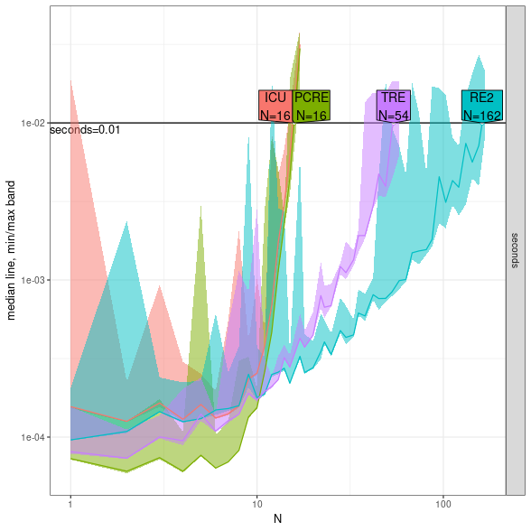

```r
plot(all.pred)
```

The figure above shows each expression as a different colored curve, each with a direct label to indicate the throughput at the time limit. This representation makes it easy to see which expression is fastest, and it shows numbers that you can cite to explain what data sizes are possible in the given time limit.

## `atime_grid` to compare different engines

```r
(nc.exprs <- atime::atime_grid(
  list(ENGINE=c(
    if(requireNamespace("re2"))"RE2",
    "PCRE",
    if(requireNamespace("stringi"))"ICU")),
  nc=nc::capture_first_vec(subject, pattern, engine=ENGINE)))
```

```
#> $`nc ENGINE=ICU`
#> nc::capture_first_vec(subject, pattern, engine = "ICU")
#>
#> $`nc ENGINE=PCRE`
#> nc::capture_first_vec(subject, pattern, engine = "PCRE")
#>
#> $`nc ENGINE=RE2`
#> nc::capture_first_vec(subject, pattern, engine = "RE2")
#>
#> attr(,"parameters")
#>         expr.name expr.grid ENGINE
#>            <char>    <char> <char>
#> 1:  nc ENGINE=ICU        nc    ICU
#> 2: nc ENGINE=PCRE        nc   PCRE
#> 3:  nc ENGINE=RE2        nc    RE2
```

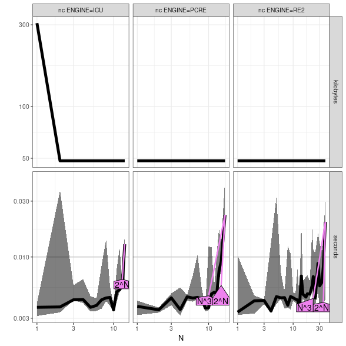

```r
nc.result <- atime::atime(
  N=subject.size.vec,
  setup={
    rep.collapse <- function(chr)paste(rep(chr, N), collapse="")
    subject <- rep.collapse("a")
    pattern <- list(maybe=rep.collapse("a?"), rep.collapse("a"))
  },
  expr.list=nc.exprs)
nc.best <- atime::references_best(nc.result)
plot(nc.best)
```

The result/plot above is consistent with the previous result.